# DSSD正背面关联（I）-归一

**目的：**

- 1. 掌握利用正背面关联对DSSD归一；
- 1. ROBUST fit方法；

**原理：**

- 硅条上一个hit会在正背面产生等量异号的感应电荷，由$E_{i} = E_{j}$。

**方法1：**

- 1. $X_{r}$为参考条，归一$Y_{j}$，有$X_{r} = k_{yj} * Y_{j} + b_{yj}, j = 0,1,...,31$;
- 1. $Y_{r}$为参考条，归一$X_{i}$，有$Y_{r} = k_{xi} * X_{i} + b_{xi}, i = 0,1,...,31$;
- 1. 当2中X中i条为参考条r时，有$Y_{r} = k_{xr} * X_{r} + b_{xr}$；有$Y_{r} = k_{xr} * k_{yj} * Y_{j} + k_{xr} * b_{yj} + b_{xr}$；此时Y方向也归一到$Y_{r}$条；

**优势：**

- 挑选条间事件；
- 排除Ghost hit；

## 打开data_16C.root文件

```python
//%jsroot on
TFile *ipf = new TFile("../data_16Cs.root");
TTree *tree = (TTree*)ipf->Get("tree");
TCanvas *c1=new TCanvas("c1","c1");
```

```python
tree->Scan("d1xe:d1xs:d1ye:d1ys","","",10,1);
```

```
*    Row   * Instance *      d1xe *      d1xs *      d1ye *      d1ys *
*        1 *        0 *      4800 *        17 *      5775 *        18 *
*        1 *        1 *       982 *        18 *           *           *
*        2 *        0 *      3069 *        23 *      3352 *        11 *
*        2 *        1 *       341 *        24 *       111 *        10 *
*        3 *        0 *      5325 *        23 *      4522 *        15 *
*        3 *        1 *           *           *       922 *        16 *
*        4 *        0 *      5822 *        21 *      5688 *        15 *
*        4 *        1 *           *           *       271 *        14 *
*        5 *        0 *      4048 *        11 *      5213 *        12 *
*        5 *        1 *      1149 *        12 *           *           *
*        6 *        0 *      3719 *        14 *      4255 *        16 *
*        6 *        1 *       374 *        13 *           *           *
*        7 *        0 *      4546 *        12 *      4961 *         9 *
*        7 *        1 *       297 *        11 *           *           *
*        8 *        0 *      4051 *        22 *      3877 *         9 *
*        8 *        1 *           *           *       329 *        10 *
*        9 *        0 *      6720 *        13 *      6513 *        12 *
*        9 *        1 *       142 *        10 *       418 *        13 *
*        9 *        2 *       109 *        14 *           *           *
*       10 *        0 *      3873 *        20 *      3007 *         8 *
*       10 *        1 *           *           *       974 *         9 *
```

**PS:hit结构中事件已按照能量降低的顺序排序**

## 查看关联

**inter-strip correlation**

- 一般情况下，条间事件的比例 = 条间面积/探测器灵敏面积；
- 本实验中，由于触发的原因，相邻条能量共享事件的比例大大增加；

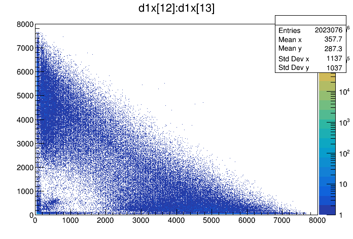

```python
tree->Draw("d1x[12]:d1x[13]>>(1000,0,8000,1000,0,8000)","","colz");//inter-strip correlation
gPad->SetLogz();
c1->Draw();
```

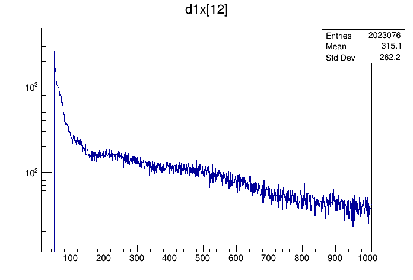

```python
tree->Draw("d1x[12]>>(1000,10,1010)","","colz");
gPad->SetLogy();
c1->Draw();
```

**front-back correlation**

- 由于x面和y面有相邻条之间的能量共享，可以看到中间直线区域(front-back)外有很多散点的分布。

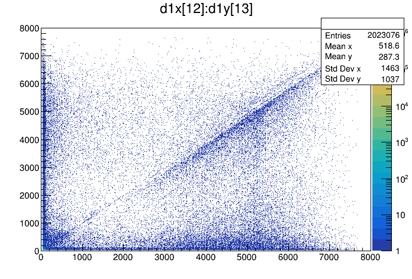

```python
gPad->SetLogy(0);
tree->Draw("d1x[12]:d1y[13]>>(1000,0,8000,1000,0,8000)","","colz");
c1->Draw();//front-back correlation
```

## 挑选有效信号

**要求两侧只有一重信号**

- 散点减少；
- 显示不同条的能量刻度系数不一致，需要刻度；

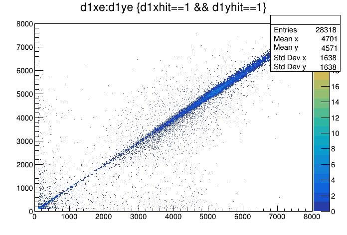

```python
//所有x条和y条正背面关联，都选择一重事件
TCut chit="d1xhit==1 && d1yhit==1";
tree->Draw("d1xe:d1ye>>(1000,0,8000,1000,0,8000)",chit,"colz");
gPad->SetLogz(0);
c1->Draw();
```

**x面，y面各选定某一条，并且两侧只有一重信号**

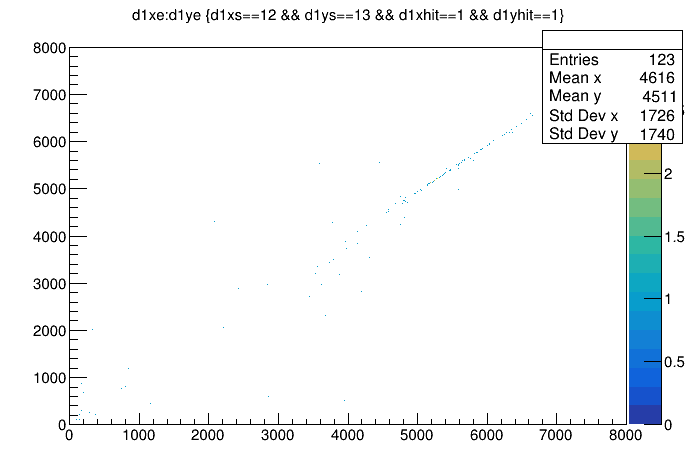

```python
TCut chit1="d1xs==12 && d1ys==13 && d1xhit==1 && d1yhit==1";
tree->Draw("d1xe:d1ye>>(1000,0,8000,1000,0,8000)",chit1,"colz");
c1->Draw();
```

PS：条件太严格，统计太少；

**改进的关联条件**

- 获取的条件为某一面的hit=2，因此事件中hit=1的事件很少。
- 在前期的数据处理过程中，去掉了一些不满足时间条件的信号，导致有些x面事件的多重性由2降为1。
- 改进的条件：不对多重性作限制，而只要求x和y面相邻条没有共享信号。

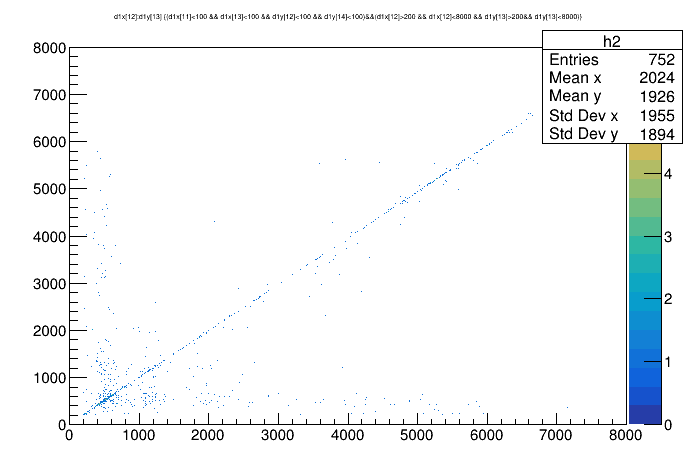

```python
TCut cveto="d1x[11]<100 && d1x[13]<100 && d1y[12]<100 && d1y[14]<100";//no crosstalk from neighbouring strips
TCut c1213="d1x[12]>200 && d1x[12]<8000 && d1y[13]>200&& d1y[13]<8000";
tree->Draw("d1x[12]:d1y[13]>>h2(1000,0,8000,1000,0,8000)",cveto&&c1213,"colz");//front-back correlation with crosstalk rejection
c1->Draw();
```

## 拟合

**TH2转成TGraph进行拟合**

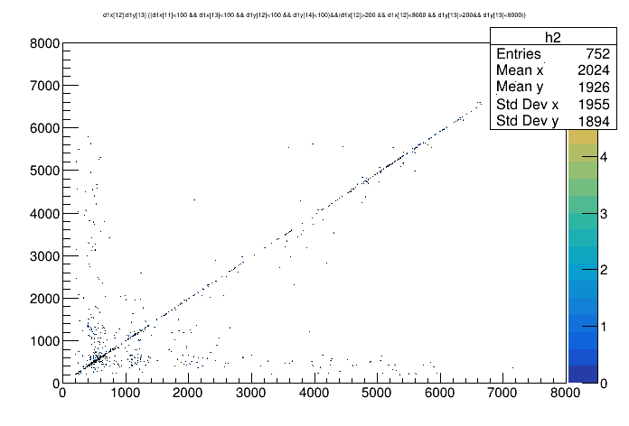

```python
TGraph *gr = new TGraph(tree->GetSelectedRows(),tree->GetV2(), tree->GetV1());
gr->Draw("p");//draw point
c1->Draw();
```

```
Minimizer is Linear
Chi2                      =   1.1529e+09
NDf                       =          750
p0                        =       442.64   +/-   65.0783
p1                        =     0.732927   +/-   0.0231293
```

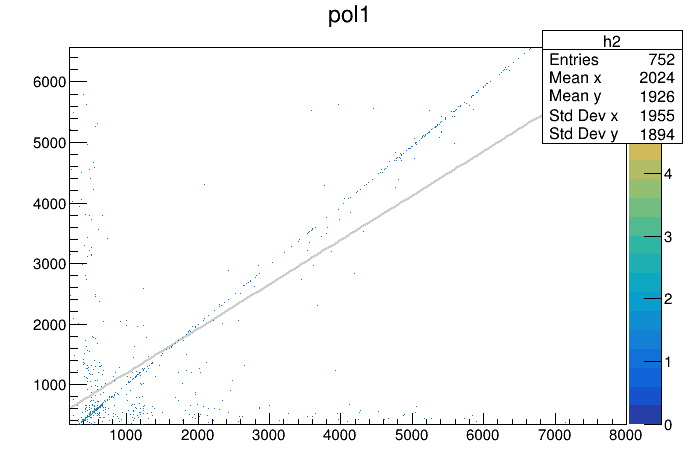

```python
TF1 *fp1= new TF1("fp1","pol1",200,8000);
fp1->SetLineColor(kGray);
gr->Fit(fp1);
fp1->Draw();
h2->Draw("same colz");
c1->Draw();
```

**拟合结果与直觉不符！**

- 在直线外存在大量散点(outliers,不是由于统计涨落引起的，是由于其他机制导致的)，影响拟合结果。
- 可以通过人为选择拟合区域(TCutG)，改善拟合。但这取决于cut范围，拟合结果随着cut范围变化而变化。

## ROTUST REGRESSION

```
Minimizer is Linear / Robust
Chi2                      =  1.33686e+09
NDf                       =          750
p0                        =      16.4611
p1                        =     0.982673
```

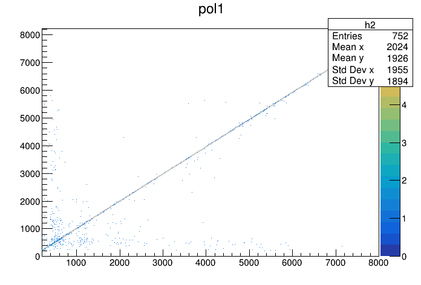

```python
Double_t p0,p1,p2;
gr->Fit(fp1,"ROB");
   //The option "rob=0.75" means that we want to use robust fitting and
   //we know that at least 75% of data is good points (at least 50% of points
   //should be good to use this algorithm). If you don't specify any number
   //and just use "rob" for the option, default value of (npoints+nparameters+1)/2
   //will be taken
p0=fp1->GetParameter(0);
p1=fp1->GetParameter(1);
fp1->Draw();
h2->Draw("same colz");
c1->Draw();
```

## 查看残差分布

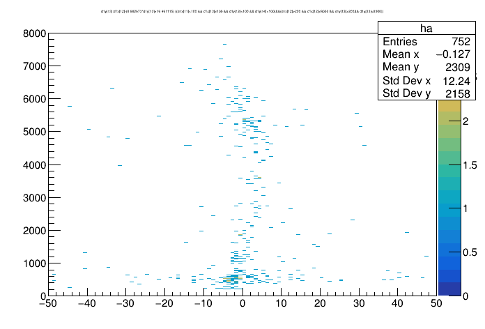

```python
TString stree;
stree.Form("d1y[13]:d1x[12]-(%lf*d1y[13]+%lf)>>ha(100,-50,50,1000,0,8000)",p1,p0);//%lf-Double_t
tree->Draw(stree.Data(),cveto&&c1213,"colz");//front-back correlation with crosstalk rejection
c1->Draw();//从图上看，一次函数拟合并不是很好
```

**PS：可以看出一次多项式拟合的残差分布不是随机的。**